[figure not shown]

# Machine Learning Programming Workshop

## 3.3 Tensorflow/Keras (Computer Vision)

#### Prepared By: [Cheong Shiu Hong (FTFNCE)](https://www.linkedin.com/in/cheongshiuhong/)

## Contents

- 1) Introduction to Computer Vision
- 2) Sci-kit Learn
- 3) Artificial Neural Network
- 4) Convolutional Neural Network
- 5) Exercise with CIFAR10 Dataset

```python
import numpy as np
import pandas as pd
import matplotlib.pyplot as plt
import time
```

```python
import tensorflow as tf
import tensorflow.keras as K
```

# Version of Tensorflow and Keras

```python
tf.__version__
```

```
'2.0.0-alpha0'
```

```python
K.__version__ # tf means Tensorflow Backend
```

```
'2.2.4-tf'
```

# 1) Introduction to Computer Vision

return to top

### Load Dataset

```python
data = K.datasets.fashion_mnist
```

```python
(train_images, train_labels), (val_images, val_labels) = data.load_data()
```

### How do computer see images?

#### Each image is a 28x28 Array carrying values of pixel intensity

```python
train_images[0].shape
```

```
(28, 28)
```

```python
img_size = train_images[0].shape[0]
print(img_size)
```

```
28
```

#### In this demonstration, images are of low resolution (28x28) and are Black & White

#### What would the array look like for RGB images?

#### Normally, we will have to pre-process the images to standardize the resolution and shape of the image.

Numpy - Tranpose, Reshape, Resize

```python
train_images.shape, train_labels.shape
```

```
((60000, 28, 28), (60000,))
```

```python
val_images.shape, val_labels.shape
```

```
((10000, 28, 28), (10000,))
```

```python
class_names = [
    'T-Shirt/Top',
    'Trousers',
    'Pullover',
    'Dress',
    'Coat',
    'Sandal',
    'Shirt',
    'Sneaker',
    'Bag',
    'Ankle Boot'
]

num_classes = len(class_names)
```

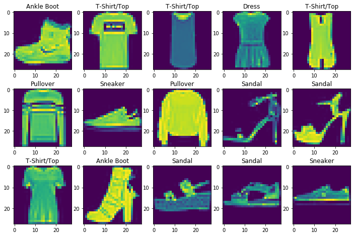

```python
horiz = 5; vert = 3; area = vert*horiz;
fig = plt.figure(figsize=(12,8))
for i in range(area):
    ax = plt.subplot(vert,horiz,i+1)
    ax.set_title(class_names[train_labels[i]])
    ax.imshow(train_images[i])#, cmap=plt.cm.binary)n
```

### Rescale Arrays (Image arrays have large integer values)

#### Pixel values need not be of any distribution, but its range is between 0 and 255.

```python
train_images = train_images / 255.0
val_images = val_images / 255.0
```

# 2) Sci-kit Learn

return to top

### Reshape Images (Flatten)

```python
reshaped_train = train_images[:2500].reshape(2500, img_size*img_size)
reshaped_val = val_images[:2500].reshape(2500, img_size*img_size)
```

```python
reshaped_train.shape, reshaped_val.shape
```

```
((2500, 784), (2500, 784))
```

### Logistic Regression

```python
from sklearn.linear_model import LogisticRegression
```

```python
log_reg = LogisticRegression()
```

```python
log_reg.fit(reshaped_train, train_labels[:2500])
```

```
LogisticRegression(C=1.0, class_weight=None, dual=False, fit_intercept=True,
          intercept_scaling=1, max_iter=100, multi_class='warn',
          n_jobs=None, penalty='l2', random_state=None, solver='warn',
          tol=0.0001, verbose=0, warm_start=False)
```

```python
log_reg.score(reshaped_val, val_labels[:2500])
```

```
0.8288
```

# 3) Artificial Neural Networks

return to top

### Let's Build a Neural Network with Keras

```python
model = K.Sequential([
    K.layers.Flatten(input_shape=(img_size, img_size)), # Flattens 28 x 28 Image into 784
    K.layers.Dense(32, activation='relu'),
    K.layers.Dense(16, activation='relu'),
    K.layers.Dense(num_classes, activation='softmax')
])
```

```python
model.compile(optimizer='adam', loss='sparse_categorical_crossentropy', metrics=['accuracy'])
```

```python
model.fit(train_images, train_labels, epochs=5, batch_size=32)
```

```
<tensorflow.python.keras.callbacks.History at 0x152395857b8>
```

```python
model.evaluate(val_images, val_labels) # ADAM
```

```
[0.41318217957019804, 0.8464]
```

```python
model.predict([[val_images[0]]])
```

```
array([[2.8331954e-07, 1.2984191e-08, 2.6422391e-05, 5.8322503e-06,
        1.4101613e-06, 2.7249558e-02, 2.9521530e-06, 5.5209454e-02,
        4.3936077e-04, 9.1706467e-01]], dtype=float32)
```

[figure not shown]

```python
fig = plt.figure(figsize=(15,7))
for i in range(10):
    ax = plt.subplot(2,5,i+1)
    ax.imshow(val_images[i], cmap=plt.cm.binary)
    ax.set_title('Actual: {}'.format(class_names[val_labels[i]]))
    ax.set_xlabel('Predicted: {}'.format(class_names[np.argmax(model.predict([[val_images[i]]]))]))
```

# 4) Convolutional Neural Networks

return to top

#### Keras Conv2D Layer takes in (B, Sv, Sh, C) where C is the the number of channels (3 for RGB, 1 for Black & White)

*PyTorch's Convolutional Layer in contrast, takes in (B, C, Sv, Sh)*

```python
conv_train_images = train_images.reshape(train_images.shape[0], img_size, img_size, 1)
conv_val_images = val_images.reshape(val_images.shape[0], img_size, img_size, 1)
```

```python
conv_train_images.shape, conv_val_images.shape
```

```
((60000, 28, 28, 1), (10000, 28, 28, 1))
```

```python
conv_model = K.Sequential([
    K.layers.Conv2D(8, (3,3), padding='same', activation='relu'),
    K.layers.MaxPooling2D(pool_size=(2,2)),
    K.layers.Conv2D(8, (3,3), padding='same', activation='relu'),
    K.layers.MaxPooling2D(pool_size=(2,2)),
    K.layers.Flatten(),
    K.layers.Dense(16, activation='relu'),
    K.layers.Dense(8, activation='relu'),
    K.layers.Dense(num_classes, activation='softmax')
])
```

```python
conv_model.compile(optimizer='adam', loss='sparse_categorical_crossentropy', metrics=['accuracy'])
```

```python
conv_model.fit(conv_train_images, train_labels, epochs=5)
```

```
<tensorflow.python.keras.callbacks.History at 0x15239aff358>
```

```python
conv_model.evaluate(conv_val_images, val_labels)
```

```
[0.4280245749235153, 0.8457]
```

[figure not shown]

```python
fig = plt.figure(figsize=(15,7))
for i in range(10):
    ax = plt.subplot(2,5,i+1)
    ax.imshow(val_images[i], cmap=plt.cm.binary)
    ax.set_title('Actual: {}'.format(class_names[val_labels[i]]))
    ax.set_xlabel('Predicted: {}'.format(class_names[np.argmax(conv_model.predict([[conv_val_images[i]]]))]))
```

### Artificial Neural Network

```python
model.summary()
```

```
Model: "sequential"
_________________________________________________________________
Layer (type)                 Output Shape              Param #
=================================================================
flatten (Flatten)            (None, 784)               0
_________________________________________________________________
dense (Dense)                (None, 32)                25120
_________________________________________________________________
dense_1 (Dense)              (None, 16)                528
_________________________________________________________________
dense_2 (Dense)              (None, 10)                170
=================================================================
Total params: 25,818
Trainable params: 25,818
Non-trainable params: 0
_________________________________________________________________
```

### Convolutional Neural Network

```python
conv_model.summary()
```

```
Model: "sequential_1"
_________________________________________________________________
Layer (type)                 Output Shape              Param #
=================================================================
conv2d (Conv2D)              multiple                  80
_________________________________________________________________
max_pooling2d (MaxPooling2D) multiple                  0
_________________________________________________________________
conv2d_1 (Conv2D)            multiple                  584
_________________________________________________________________
max_pooling2d_1 (MaxPooling2 multiple                  0
_________________________________________________________________
flatten_1 (Flatten)          multiple                  0
_________________________________________________________________
dense_3 (Dense)              multiple                  6288
_________________________________________________________________
dense_4 (Dense)              multiple                  136
_________________________________________________________________
dense_5 (Dense)              multiple                  90
=================================================================
Total params: 7,178
Trainable params: 7,178
Non-trainable params: 0
_________________________________________________________________
```

#### Convolutional Layers have less Trainable-Parameters and are comparatively less expensive than Dense/Recurrent Layers

#### Especially with GPU, when Convolutional Compuations are Parallelized with large Bandwidths, Convolutional Neural Networks are very effective and efficient

Can't calculate later layers before earlier layers are done, thus not too much difference between CPU and GPU

But intra-layer, each node can be calculated simultaneously, thus GPUs show advantage in parallelized computations with larger bandwidths, especially for Convolutional Layers where the same set of (3x3) Parameters are used to multiply on each set of (3x3) Pixels.

# 5) Exercise with CIFAR10 Dataset

return to top

[Details on CIFAR 10 Dataset](https://www.cs.toronto.edu/~kriz/cifar.html)

```python
from tensorflow.keras.datasets import cifar10
```

```python
data = cifar10.load_data() # ~170 Megabytes of 60,000 Images in 32 x 32 x 3
```

```python
(X_train, Y_train), (X_val, Y_val) = data
```

```python
X_train.shape, Y_train.shape, X_val.shape, Y_val.shape
```

```
((50000, 32, 32, 3), (50000, 1), (10000, 32, 32, 3), (10000, 1))
```

```python
img_size = X_train.shape[1]
num_channels = X_train.shape[3]
```

```python
class_names = [
    'airplane',
    'automobile',
    'bird',
    'cat',
    'deer',
    'dog',
    'frog',
    'horse',
    'ship',
    'truck'
]

num_classes = len(class_names)
```

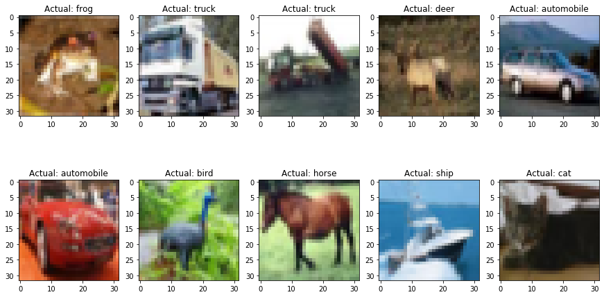

```python
fig = plt.figure(figsize=(15,8))
for i, image in enumerate(X_train[:10]):
    ax = plt.subplot(2, 5, i+1)
    ax.imshow(image)
    ax.set_title('Actual: {}'.format(class_names[Y_train[i][0]]))
```

#### Scale Pixel Values to 0-1

```python
X_train = X_train / 255.
X_val = X_val / 255.
```

```python
X_train.shape
```

```
(50000, 32, 32, 3)
```

#### Build Model

```python
conv_model = K.Sequential([
    K.layers.Conv2D(32, (3,3), padding='same', activation='relu', input_shape=(32,32,3,)),
    K.layers.MaxPooling2D(pool_size=(2,2)),
    K.layers.Conv2D(16, (3,3), padding='same', activation='relu'),
    K.layers.MaxPooling2D(pool_size=(2,2)),
    K.layers.Conv2D(8, (3,3), padding='same', activation='relu'),
    K.layers.MaxPooling2D(pool_size=(2,2)),
    K.layers.Flatten(),
    K.layers.Dense(32, activation='relu'),
    K.layers.Dense(num_classes, activation='softmax')
])
```

```python
conv_model.compile(optimizer='adam', loss='sparse_categorical_crossentropy', metrics=['accuracy'])
```

#### Train Model

```python
conv_model.fit(X_train, Y_train, epochs=2, batch_size=32)
```

```
<tensorflow.python.keras.callbacks.History at 0x1523be95128>
```

#### The good thing about working in Jupyter Notebook is that you can continue training the model in the next cell without saving the model

```python
# Epoch 3
conv_model.fit(X_train, Y_train, epochs=1, batch_size=32, verbose=0) # You can play around with the different arguments
# Verbose 0 means Silent (Nothing printed out)
```

```
<tensorflow.python.keras.callbacks.History at 0x1525f949198>
```

```python
# Epoch 4
conv_model.fit(X_train, Y_train, epochs=1, batch_size=32, verbose=2) # You can play around with the different arguments
# Verbose 2 means no Progress Bar (Default is Verbose 1, with Progress Bar)
```

```
50000/50000 - 30s - loss: 1.1948 - accuracy: 0.5775
```

```
<tensorflow.python.keras.callbacks.History at 0x1525f949978>
```

```python
# Epoch 5
conv_model.fit(X_train, Y_train, epochs=1, batch_size=32, ) # You can play around with the different arguments
# Verbose 2 means no Progress Bar (Default is Verbose 1, with Progress Bar)
```

```
<tensorflow.python.keras.callbacks.History at 0x1525f949e80>
```

#### Evaluate Performance of Model

```python
conv_model.evaluate(X_val, Y_val)
```

```
[1.102982096672058, 0.6059]
```

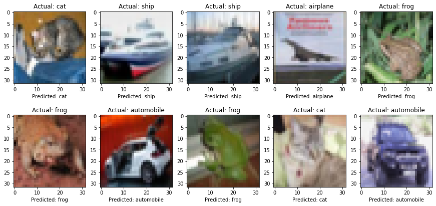

```python
fig = plt.figure(figsize=(15,7))
for i in range(10):
    ax = plt.subplot(2,5,i+1)
    ax.imshow(X_val[i], cmap=plt.cm.binary)
    ax.set_title('Actual: {}'.format(class_names[Y_val[i][0]]))
    ax.set_xlabel('Predicted: {}'.format(class_names[np.argmax(conv_model.predict([[X_val[i]]]))]))
```

### Saving / Loading the Model

#### Saving the Model

```python
conv_model.save('conv_model.h5')
```

#### Deleting the Model

```python
del conv_model
```

```python
try: print(conv_model)
except: print("NameError: name 'conv_model' is not defined")
```

```
NameError: name 'conv_model' is not defined
```

#### Loading the Model from saved file

```python
conv_model = K.models.load_model('conv_model.h5')
```

```python
conv_model.evaluate(X_val, Y_val)
```

```
[1.102982096672058, 0.6059]
```

#### Testing the Model with New Images

```python
import os
from PIL import Image
```

```python
root = './sources/test_images/'

full_images = []
filenames = [name for name in os.listdir(root)]

for filename in filenames:
    img = Image.open(root+filename)
    img.load()
    full_images.append(np.asarray(img, dtype='int32'))
```

[figure not shown]

```python
fig = plt.figure(figsize=(15,8))
for i, image in enumerate(full_images):
    ax = plt.subplot(2, 5, i+1)
    ax.imshow(image)
    ax.set_title('Filename: {}'.format(filenames[i]))
```

#### Reload images as 32 x 32 x 3 Arrays

```python
images = []
filenames = [name for name in os.listdir(root)]
root = './sources/test_images/'
for filename in filenames:
    img = Image.open(root+filename)
    img.load()
    img = img.resize(size=(img_size, img_size))
    images.append(np.asarray(img, dtype='int32'))
images = np.array(images)
```

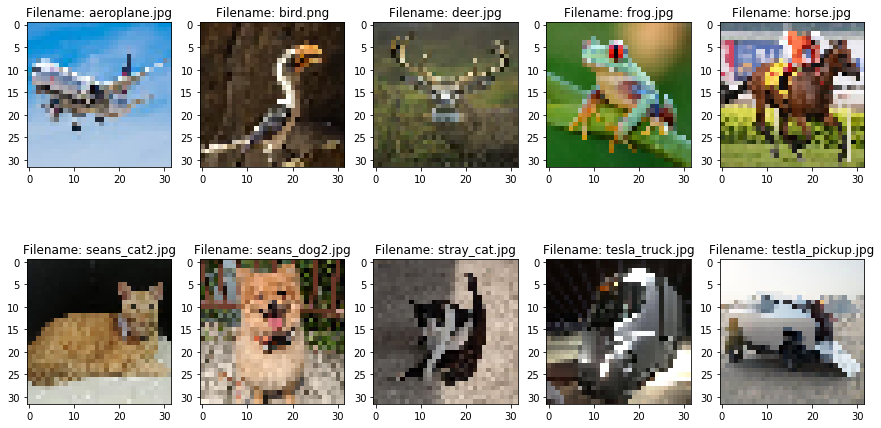

```python
fig = plt.figure(figsize=(15,8))
for i, image in enumerate(images):
    ax = plt.subplot(2, 5, i+1)
    ax.imshow(image)
    ax.set_title('Filename: {}'.format(filenames[i]))
```

#### Predictions

```python
preds = np.argmax(conv_model.predict([images]), 1)
```

```python
print(preds)
```

```
[0 3 6 1 7 7 5 5 9 9]
```

[figure not shown]

```python
fig = plt.figure(figsize=(15,8))
for i, image in enumerate(full_images):
    ax = plt.subplot(2, 5, i+1)
    ax.imshow(image)
    ax.set_title('Filename: {}'.format(filenames[i]))
    ax.set_xlabel('Predicted: {}'.format(class_names[preds[i]]))
```

### How to further improve?

#### Dropout Reglarization and Batch Normalization

[figure not shown]

#### Data Augmentation

- Color Augmentation
- Cropping
- Rotating
- Flipping

### [Popular Convolutional Neural Network Architectures](https://medium.com/analytics-vidhya/cnns-architectures-lenet-alexnet-vgg-googlenet-resnet-and-more-666091488df5)

[LeNet (1998)](https://engmrk.com/lenet-5-a-classic-cnn-architecture/)

[AlexNet (2012)](https://www.learnopencv.com/understanding-alexnet/)

[GoogLeNet/InceptionNet (2014)](https://towardsdatascience.com/a-simple-guide-to-the-versions-of-the-inception-network-7fc52b863202)

[VGGNet (2014)](https://www.pyimagesearch.com/2017/03/20/imagenet-vggnet-resnet-inception-xception-keras/)

[ResNet (2015)](https://towardsdatascience.com/introduction-to-resnets-c0a830a288a4)

#### You can even load models pre-trained on large datasets and retrain only the last few layers

[Transfer Learning 1](https://towardsdatascience.com/keras-transfer-learning-for-beginners-6c9b8b7143e)

[Transfer Learning 2](https://medium.com/@14prakash/transfer-learning-using-keras-d804b2e04ef8)

Previous: Next:

Introduction to Neural Networks Tensorflow/Keras (Natural Language)